# Mini-Project #4

Author

Jason Stasio

**Bayesian Analysis**

## Introduction

The goal of this project is to apply a Bayesian approach to modeling the probability that Rafael Nadal, one of the world’s greatest men’s clay-court tennis players, wins a point on his own serve against his primary rival, Novak Djokovic, during the French open tournament. It investigates how the data transforms three different scenarios/prior distributions, a noninfoirmative prior where we know nothing about the probability of Nadal scoring, an informative prior based on a previous clay-court match where Nadal won 46 out of 66 points with standard error 0.05657, and an informative prior based on a sports announcer’s claim that Nadal wins the point about 75% of the time and never less than 70% of the time. First, the prior distributions are determined and graphed, with justification for choices included along with the code. Next, the data is applied to the prior to create the posterior distributions, which are determined and graphed. Calculations associated with these determinations are also included in the body using built-in latex. Along with graphing the posterior distributions, their means and associated 90% credible intervals are determined, with the method used to obtain these values given. Finally, a comparison and conclusion will be conducted to interpret the results.

## Body

#### Set-up

```r
# Clear the environment
rm(list = ls())

# Load in packages
library(tidyverse)
```

#### Prior Distributions

```r
ps <- seq(0, 1, length.out = 1000)

# Prior 1: Non-informative

# We will use a beta distribution with alpha=1 and beta=1 (equivalent to uniform(0,1)) to represent our non-informative prior since it is flat and thus any value between 0 and 1 holds equal density.

noninformative_alpha <- 1
noninformative_beta <- 1

noninformative_prior <- dbeta(ps, noninformative_alpha, noninformative_beta)

# Prior 2: Informative Based on a Clay-court Match

# Since we are given the number of points Nadal wins on his serve against Djokovic out of the total number of points for his serves, we have a proportion represented as a fraction that can take on values between 0 and 1. Thus, a beta distribution is a good choice for the prior. The general mean of the beta distribution can be set to the information given, a fraction, to solve for alpha and beta parameters. Let us note that we could also set it equal to the proportion represented as a decimal, solve for the general beta value depending on alpha, sequence alpha, then look for the values that give a standard error close to the one given. However, this would be unnecessary and computationally inefficient since we are given an exact value for the mean, which allows us to directly solve for specific alpha and beta parameters representative of the scenario.
```

$$\frac{46}{66} = \frac{\alpha}{\alpha +\beta} \implies \alpha = 46,\text{ } \beta +\alpha = 66 \implies \beta = 66 - \alpha= 66 - 46=20$$

```r
ccm_informative_alpha <- 46
ccm_informative_beta <- 20

ccm_informative_prior <- dbeta(ps, ccm_informative_alpha, ccm_informative_beta)

# Prior 3: Informative Based on Sports Announcer

# Once again, we are given information pertaining to the proportion of points Nadal wins on his serves against Djokovic, so a beta distribution is a good choice for the prior. The sports announcer claims Nadal wins 75% of the points on his serve against Djokovic, which corresponds to the proportion 0.75. He also says he is "almost" sure Nadal wins no less than 70% of his serves, so we can adopt the strategy of solving for the beta parameter depending on alpha, sequencing through alpha values, calculating the distance to having a probability of 0.02 (a small value) of being less than 0.7 based on the parameters and filtering to find the smallest one. The parameters associated with the smallest distance to our target probability will be used.
```

$$0.75 = \frac{\alpha}{\alpha + \beta}\implies 0.75\alpha +0.75\beta=\alpha\implies0.75\beta=0.25\alpha \implies \beta =\frac{0.25\alpha}{0.75}$$

```r
alphas <- seq(1, 1000, length.out = 5000)
betas <- (0.25 * alphas) / 0.75

target_prob <- 0.02
prob_less_2 <- pbeta(0.7, alphas, betas)

tibble(alphas, betas, prob_less_2) |>
  mutate(close_to_target = abs(prob_less_2 - target_prob)) |>
  filter(close_to_target == min(close_to_target))
```

```
# A tibble: 1 × 4
  alphas betas prob_less_2 close_to_target
   <dbl> <dbl>       <dbl>           <dbl>
1   252.  83.9      0.0200     0.000000320
```

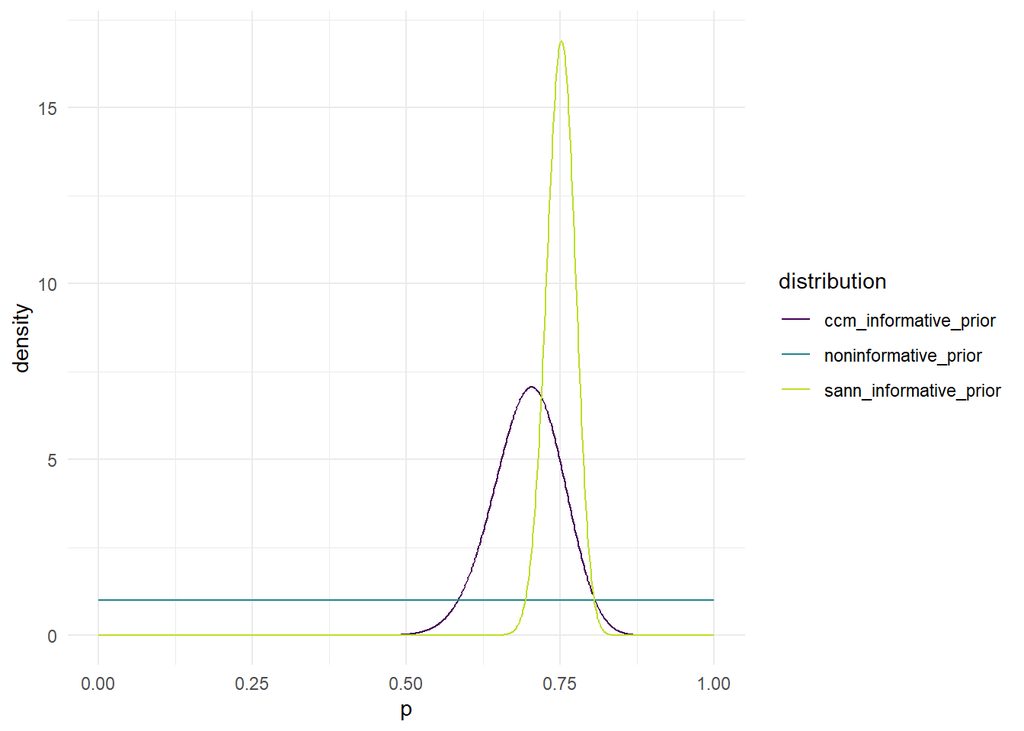

```r
sann_informative_alpha <- 252
sann_informative_beta <- 83.9

sann_informative_prior <- dbeta(ps, sann_informative_alpha, sann_informative_beta)

plot_df_prior <- tibble(ps, noninformative_prior,
                  ccm_informative_prior,
                  sann_informative_prior) |>
  pivot_longer(cols = -ps, names_to = "distribution", values_to = "density")

ggplot(data = plot_df_prior, aes(x = ps, y = density, colour = distribution)) +
  geom_line() +
  scale_colour_viridis_d(end = 0.9) +
  theme_minimal() +
  labs(x = "p")
```